# snATAC ArchR initial QC report FC

Darren Cameron

09/02/22

snATACseq analysis with ArchR.

### Results

#### QC

ArchR takes the fragments file as input. This is different from Signac/Seurat which takes the filtered read matrix generated by Cell Ranger as input.

ArchR pre-filters the cells using thresholds:

- TSS Enrichment > 4
- Min frags per cell > 1000

**Counts**

| Sample | Cells_Pass_Filter | Cells_dropped | Total_Frags | Median_Frags | Median_TSS_Enrichment |
| --- | --- | --- | --- | --- | --- |
| 510_FC_ | 8321 | 540 | 144627666 | 12240 | 13.947 |
| 611_FC_ | 5029 | 473 | 92412417 | 12188 | 11.668 |
| 993_FC_ | 2287 | 551 | 23664555 | 1960 | 9.853 |

**Doublet removal**

Post-doublet removal numbers are the final cell numbers moving forward.

| Sample | Pre_DoubRem | Post_DoubRem | pc_cells_removed |
| --- | --- | --- | --- |
| 510_FC_ATAC | 8321 | 7629 | 8.316308 |
| 611_FC_ATAC | 5029 | 5029 | 0.000000 |
| 993_FC_ATAC | 2287 | 2235 | 2.273721 |

**Pre-filter plots**

**TSS enrichment vs. log10(Number of fragments) - these are the pre-filtered results**

If you want to compare these results to others studies check out page 4 of the [ArchR supplementary document](https://static-content.springer.com/esm/art%3A10.1038%2Fs41588-021-00790-6/MediaObjects/41588_2021_790_MOESM1_ESM.pdf).

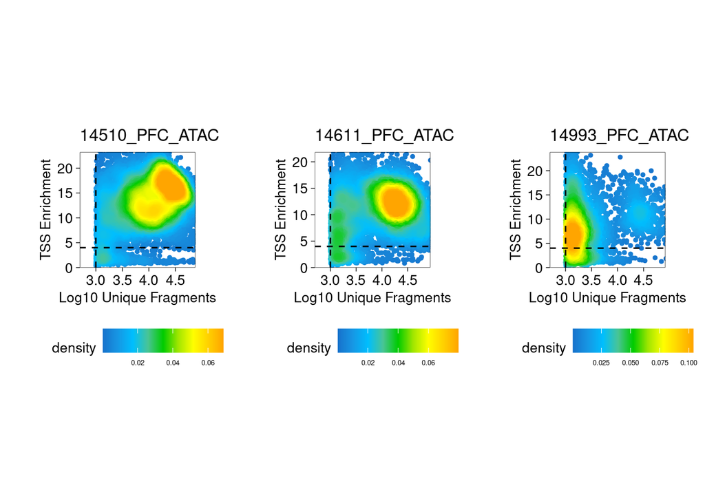

**Post-filter plots**

**TSS enrichment vs. log10(Number of fragments) plot - all samples combined**

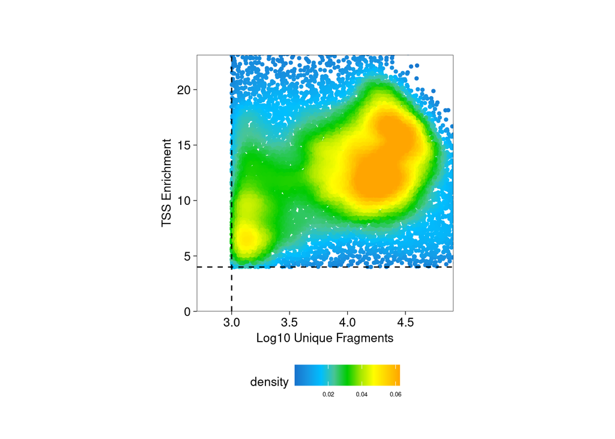

**Fragment size plot**

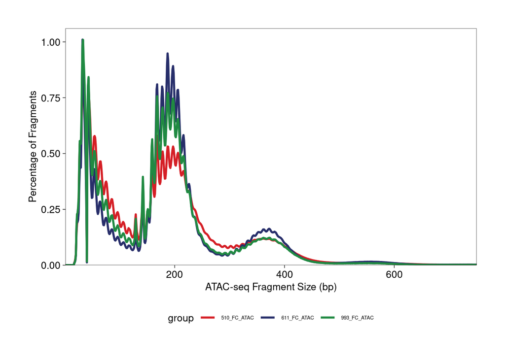

**TSS plot**

NOTE: There is a bug in the software, as all of the plots TSS plots look the same! I’ve added a second ridge plot below which shows the same thing.

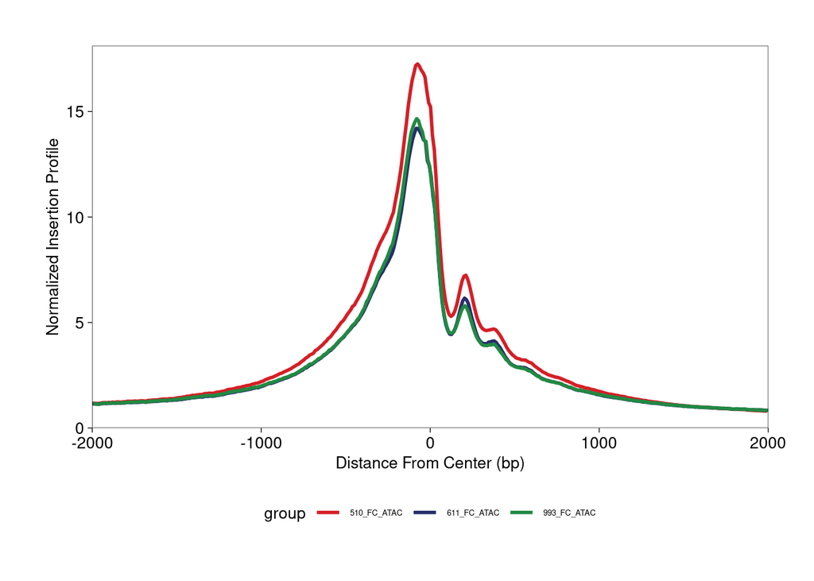

**Ridge plot**

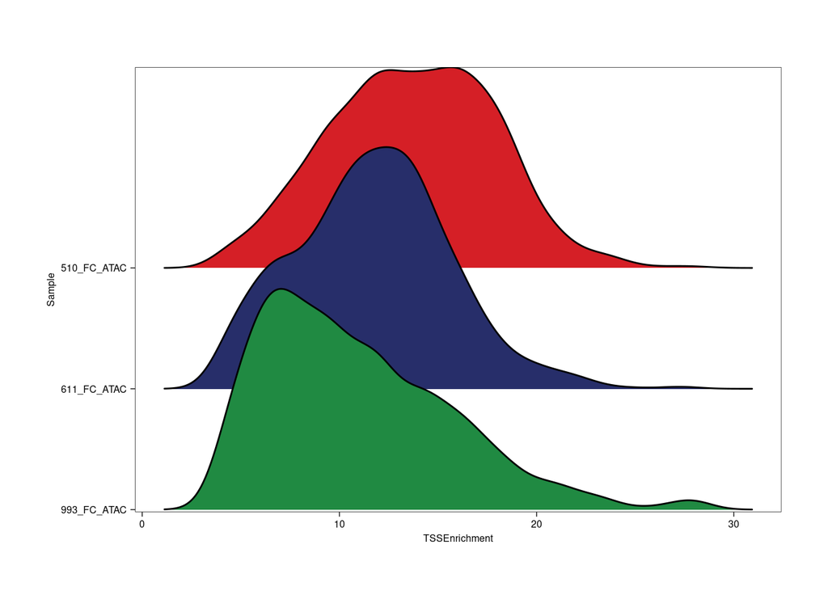

#### Clusters

**Pre-batch corrected clusters**

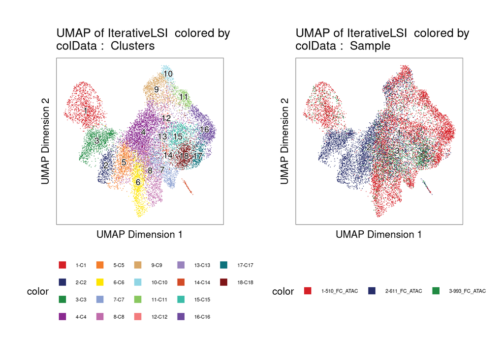

**Cell counts per cluster**

| C1 | C10 | C11 | C12 | C13 | C14 | C15 | C16 | C17 | C18 | C2 | C3 | C4 | C5 | C6 | C7 | C8 | C9 |
| --- | --- | --- | --- | --- | --- | --- | --- | --- | --- | --- | --- | --- | --- | --- | --- | --- | --- |
| 1200 | 270 | 419 | 217 | 509 | 150 | 886 | 1075 | 489 | 903 | 527 | 1079 | 2342 | 881 | 1021 | 806 | 1257 | 862 |

**Confusion Matrix**

Showing cell counts per donor in each cluster. The threshold for cluster inclusion at this stage is clusters must have at least 10 cells from 2 out of 3 donors to be included in downstream analyses.

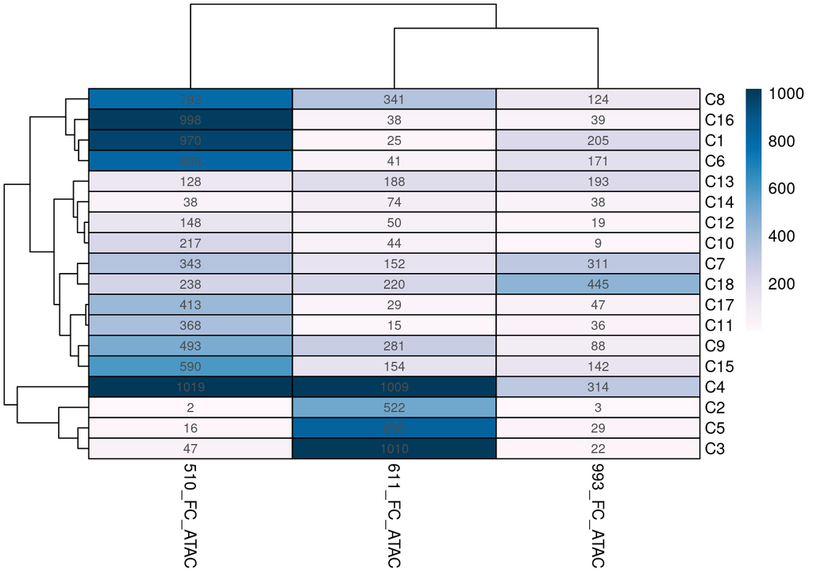